# Class 07

2023-10-12

# Instructions

Create a Quarto markdown document (**using the provided template**) and answer the questions below using code blocks that generate the correct outputs. We encourage you to include explanatory text in your markdown document, however **each of your solutions should show how to generate the answer using R code** **OR if you are unable to generate the exact solution, include the commented-out non-functional code with text explaining how you attempted to solve it, and what you think is causing the problem.**

Write “robust” solutions wherever possible. A good rule of thumb for judging whether your solution is appropriately “robust” is to ask yourself “If I added additional observations or variables to this data set, or if the order of variables changed, would my code still compute the right solution?”

Make sure your markdown is nicely formatted – use headers, bullets, numbering, etc so that the structure of the document is clear.

Make sure to “Render” your document before submission to confirm that all code blocks and formatting is as you expect.

When completed, title your markdown file as follows (replace XX with the assignemnt number, e.g. 01, 02, etc):

- netid-assignment_XX-Fall2023.qmd

Submit both your markdown file (.qmd) and the generated HTML document (.html) via the Assignments submission section on Sakai.

# Data set: Bird Cognition Data

Danae Diaz (another grad student in our department) spent the summer gathering data to test her hypothesis that metal contamination affects bird cognition (I’m simplifying her actual experiment here–feel free to reach out to her to learn the full story). She used “puzzle boxes” at four field sites with varying levels of metal contamination and measured how long it took the birds to complete the puzzle (again, I’m simplifying things). She re-ran the puzzle 6 times over one day for each bird and recorded the following variables:

- The date on which she ran the experiment: `Date`
- The sex of the bird: `Sex`
- The time it took the birds to complete the puzzle (in minutes) for each trial: Trial 0 `X0.5` Trial 1 `X1`Trial 2 `X2`Trial 3 `X3`Trial 4 `X4` and Trial 5 `X5`
- A two-letter abbreviation for the field site, and the number designation for the puzzle box: `SiteBox`

She also recorded in a separate data sheet “Site contamination”:

- The full name for each field site: `SiteName`
- The matching two letter abbreviation she used in the bird cognition data set: `ID`
- A ranking of the level of contamination, where 1 was the most contaminated site and 4 was the least: `Contamination Level (1=most)`

Please note that the values included here are NOT the values from Danae’s actual experiment–they have been manipulated to allow us to practice the skills we’ve learned in this class. Nevertheless, some of the wrangling problems you will encounter are true to the original data sheet, and others are extremely common issues you will repeatedly encounter throughout your career.

### Looking Ahead:

In this problem set, you will be asked to pull together the skills you have learned so far in this course to answer the following questions:

- Is there a sex difference in how quickly the birds complete the puzzle?
- Does metal contamination seem to affect how quickly the birds complete the puzzle?
- Is there co-variation between sex-differences and field site differences?
- Does the time-of-year in which the trial was run seem to impact how quickly the birds completed the puzzle? (i.e. did birds complete the puzzle quicker at the beginning of the summer).
- Is there any difference in the rate at which the birds learned to solve the puzzle over each trial by sex or by field site?

To answer these questions, we will need to split data by both position and by a deliminator, we will need to pivot the data from wide to long, we will need to join two data sets, and we will need to coerce columns into different data types (and more!)

Are you ready?

# Problem 1: Importing the Data and Loading Packages

Load the package `tidyverse`

Import the data `Site contamination key.csv` and name it `key`, then import the data `Bird Cognition Data for Class.csv` and name it `df`

# Problem 2

There are currently two variables being stored in the `SiteBox` column in `df`: the field site 2-letter abbreviation, and the box number at that site. Separate `SiteBox` into two columns `Site` and `Box` using `separate_wider_position()` (hint: take a look at the argument `too_few` in the `separate_wider` functions).

```
## # A tibble: 6 × 10
##   Date         Sex    X0.5    X1    X2    X3    X4    X5 Site  Box
##   <chr>        <chr> <dbl> <dbl> <dbl> <dbl> <dbl> <dbl> <chr> <chr>
## 1 8_14_2023    M      21.1  32.2 20.4  19.6  18.8  11.9  HG    1
## 2 June_27_2023 F      14.2  12.3 14.5  11.7   7.14  9.51 HG    1
## 3 June_26_2023 F      15.0  15.4 12.0   8.74  7.84 12.5  HG    2
## 4 June_19_2023 M      38.8  19.5 24.2  15.5  21.1  10.6  HG    2
## 5 8_20_2023    M      38.1  28.0 17.5  19.1  18.2  19.1  HG    4
## 6 8_2_2023     F      13.6  10.5  5.94  8.88 11.1  10.1  HG    4
```

# Problem 3

The columns `X0.5`, `X1`, `X2`, `X3`, `X4` and `X5` are the trial number, and the values in those rows are the time it took the bird to complete that trial.

Pivot the `df` data from wide to long using `pivot_longer()` to gather the `X0.5`, `X1`, `X2`, `X3`, `X4` and `X5` columns into two columns: `Trial` and `Time` (hint: take a look at the `cols=starts_with()` argument in the `pivot_longer` function).

```
## # A tibble: 6 × 6
##   Date      Sex   Site  Box   Trial  Time
##   <chr>     <chr> <chr> <chr> <chr> <dbl>
## 1 8_14_2023 M     HG    1     X0.5   21.1
## 2 8_14_2023 M     HG    1     X1     32.2
## 3 8_14_2023 M     HG    1     X2     20.4
## 4 8_14_2023 M     HG    1     X3     19.6
## 5 8_14_2023 M     HG    1     X4     18.8
## 6 8_14_2023 M     HG    1     X5     11.9
```

# Problem 4

We want the `Trial` column to be numeric, but first we will have to get rid of the X in front of each number. Use `separate_wider_delim()` to remove these X’s (hint: you will need to make two new columns, one of which will be empty, and then remove the empty column using `select()`).

```
## # A tibble: 6 × 6
##   Date      Sex   Site  Box   Trial  Time
##   <chr>     <chr> <chr> <chr> <chr> <dbl>
## 1 8_14_2023 M     HG    1     0.5    21.1
## 2 8_14_2023 M     HG    1     1      32.2
## 3 8_14_2023 M     HG    1     2      20.4
## 4 8_14_2023 M     HG    1     3      19.6
## 5 8_14_2023 M     HG    1     4      18.8
## 6 8_14_2023 M     HG    1     5      11.9
```

# Problem 5

We want to add the site names and contamination levels contained in the `key` data frame to `df` without removing any of the values in `df`. What kind of join do we need to do? Try to come up with the answer on your own first and then hover over the text below to see if you were correct.

A left-join, with `df` on the left

Try it! If your join isn’t working, try to figure out why first, and if you’re still stuck, hover over the text below for a hint.

Check to see if the column you want to join by has the same name in each data frame. If not, you will need to use `rename()`. Rename the columns in “key” as follows: `ID`= `Site` , `ContLevel`= `Contamination Level (1=most)`

```
## # A tibble: 6 × 8
##   Date      Sex   Site  Box   Trial  Time SiteName     ContLevel
##   <chr>     <chr> <chr> <chr> <chr> <dbl> <chr>            <dbl>
## 1 8_14_2023 M     HG    1     0.5    21.1 Horton Grove         4
## 2 8_14_2023 M     HG    1     1      32.2 Horton Grove         4
## 3 8_14_2023 M     HG    1     2      20.4 Horton Grove         4
## 4 8_14_2023 M     HG    1     3      19.6 Horton Grove         4
## 5 8_14_2023 M     HG    1     4      18.8 Horton Grove         4
## 6 8_14_2023 M     HG    1     5      11.9 Horton Grove         4
```

### Problem 5a

Now let’s take a preliminary look at our data using `group_by()` and `summarise()`. Group the data by `Site` and `Sex`, then use `summarise` to get the mean `Time` by group.

```
## # A tibble: 10 × 3
## # Groups:   Site [4]
##    Site  Sex   mean.time
##    <chr> <chr>     <dbl>
##  1 HG    "F"        11.2
##  2 HG    "M"        21.9
##  3 LL    ""        NaN
##  4 LL    "F"        32.2
##  5 LL    "M"       625.
##  6 NF    ""        NaN
##  7 NF    "F"        21.7
##  8 NF    "M"        29.4
##  9 NG    "F"      1152.
## 10 NG    "M"      6127.
```

Hmmmm, it seems like something really weird is going on with our data set – can you identify a few things that seem incorrect?

Let’s use plotting to explore more!

# Problem 6

Try to make the following figure. Use `theme_classic`, and set all text to `size=20` (hint: it won’t work–keep reading to figure out why):

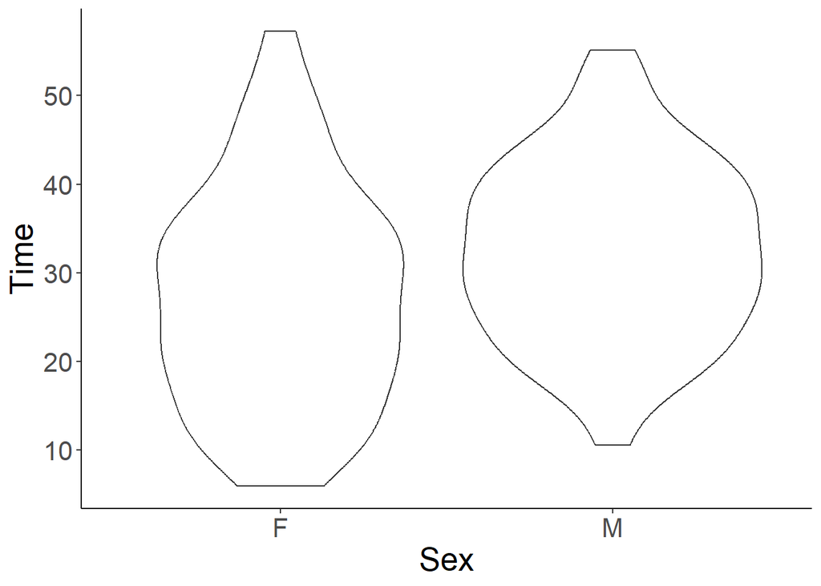

Here is the figure you are likely to have created. What went wrong? Why does it look like this? Try and find the problem first, then once you think you’ve got it figured out, hover over the text below to see the answer.

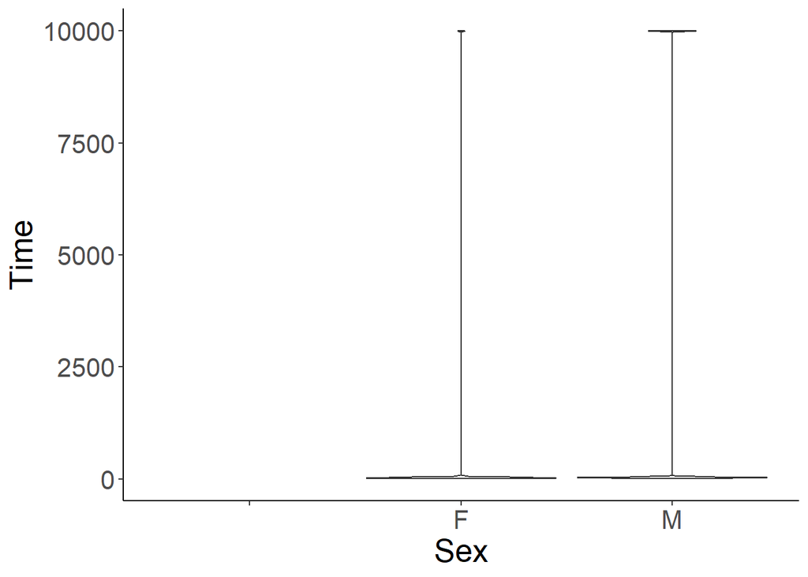

Solution: If the bird did not manage to solve the puzzle within 60 minutes, the researcher marked that as a failure. To distinguish between birds that attempted the puzzle and failed, versus missing values, she encoded these failures as “9999” (this is a semi-common way to mark NAs, but is now causing problems when we want to plot).

### Problem 6a.

Using `mutate()` and the vectorized `if_else()` statement, add a new column to `df`: `Solved` which is “Yes” if the bird attempted the puzzle and solved it in under 60 minutes, “No” if the bird attempted the puzzle but did not finish in under 60 minutes (9999), and is NA if the bird did not attempt the puzzle.

Once you have done this, use `mutate()` and the vectorized `if_else()` statement to change the `Time` column so that values above 60 are NAs

```
## # A tibble: 4 × 9
##   Date      Sex   Site  Box   Trial  Time SiteName  ContLevel Solved
##   <chr>     <chr> <chr> <chr> <chr> <dbl> <chr>         <dbl> <chr>
## 1 8_15_2023 F     LL    5     4      35.6 Lake Lynn         2 Yes
## 2 8_15_2023 F     LL    5     5      32.9 Lake Lynn         2 Yes
## 3 7_17_2023 M     LL    5     0.5    NA   Lake Lynn         2 No
## 4 7_17_2023 M     LL    5     1      47.2 Lake Lynn         2 Yes
```

Now try to remake the first figure.

There should still be something wrong–here is the plot you likely made. Why is there so much white space to the left of the figure? Try and find the problem first, then once you think you’ve got it figured out, hover over the text below to see the answer.

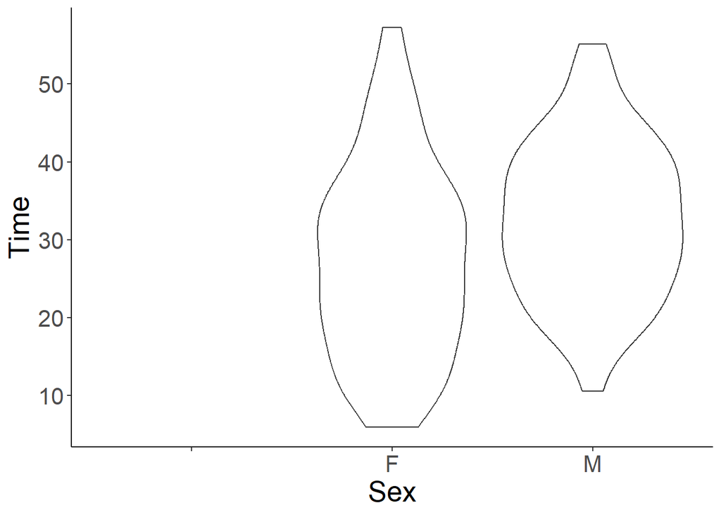

Solution: The researcher encoded her missing values as NAs, but also has some columns as blanks where she hasn’t finished collecting data!

### Problem 6b.

Using `mutate()` and a vectorized `if_else()` statement, change these blanks to NAs. From there, you will also likely need to drop all of the rows containing NAs in the `Sex` column (but not NAs in other rows) using `drop_na()`.

```
## # A tibble: 5 × 9
##   Date      Sex   Site  Box   Trial  Time SiteName  ContLevel Solved
##   <chr>     <chr> <chr> <chr> <chr> <dbl> <chr>         <dbl> <chr>
## 1 8_26_2023 M     LL    3     2      NA   Lake Lynn         2 <NA>
## 2 8_26_2023 M     LL    3     3      NA   Lake Lynn         2 <NA>
## 3 8_26_2023 M     LL    3     4      NA   Lake Lynn         2 <NA>
## 4 8_26_2023 M     LL    3     5      NA   Lake Lynn         2 <NA>
## 5 8_15_2023 F     LL    5     0.5    36.3 Lake Lynn         2 Yes
```

Now recreate the first figure (it should work this time!) and interpret the results.

### Problem 6c.

Now re-do the grouping and summarizing problem from before in 5a. Using `group_by()` and `summarise()`, group the data by `Site` and `Sex`, then use `summarise` to get the mean `Time` by group.

```
## # A tibble: 8 × 3
## # Groups:   Site [4]
##   Site  Sex   mean.time
##   <chr> <chr>     <dbl>
## 1 HG    F          11.2
## 2 HG    M          21.9
## 3 LL    F          32.2
## 4 LL    M          38.8
## 5 NF    F          21.7
## 6 NF    M          29.4
## 7 NG    F          45.9
## 8 NG    M          43.6
```

# Problem 7

Try to create the following figure (you will need to coerce the `SiteName` column to a factor and then re-level it in order of contamination).

Use `theme_classic` and set all text to `size=20`. Remove the x-axis title but not the text.

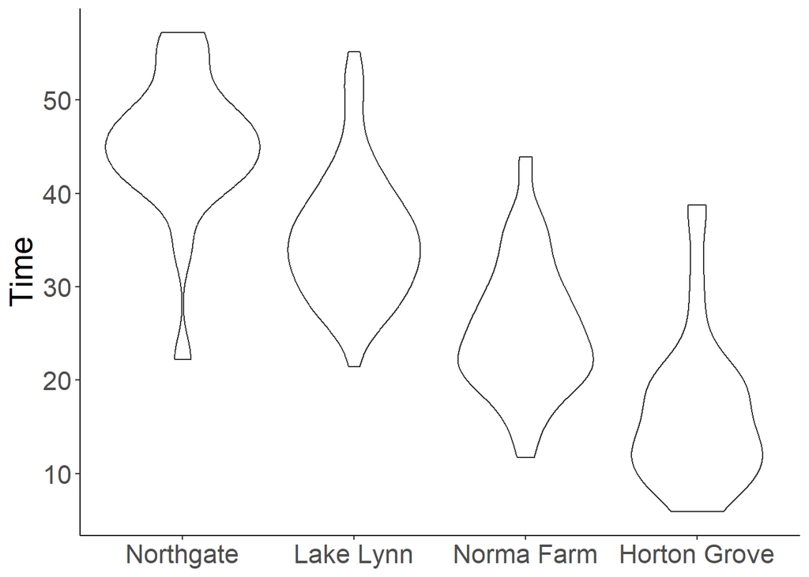

# Problem 8

Create the following figure (use `theme_classic`, set all text to `size=20` and remove the x-axis title but not the text. You are also welcome to change the colors if you want).

Interpret it: Does there seem to be a difference in the time it takes the birds to complete their puzzle by contamination level, and does there seem to be any covariation with sex differences?

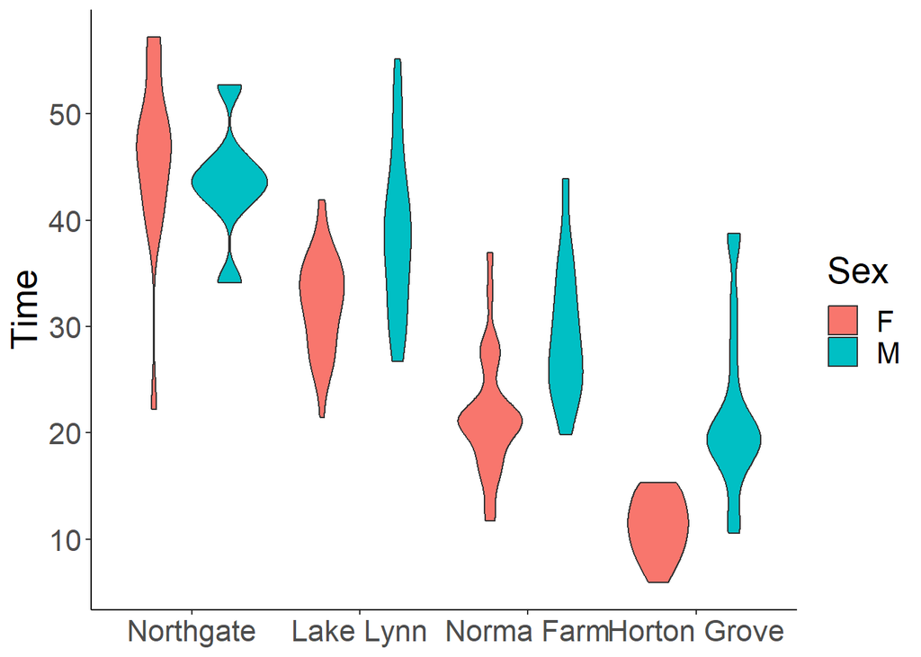

# Problem 9

Create the following figure (use `theme_classic`, set all text to `size=20` and remove the x-axis title but not the text. You are also welcome to change the colors if you want). You will need to coerce the `Site` column to a factor and then re-level it in reverse order of contamination.

Interpret it: Does there seem to be any relationship between site contamination, sex, and whether or not the bird solved the puzzle? Which sites does the researcher need to gather more data at?

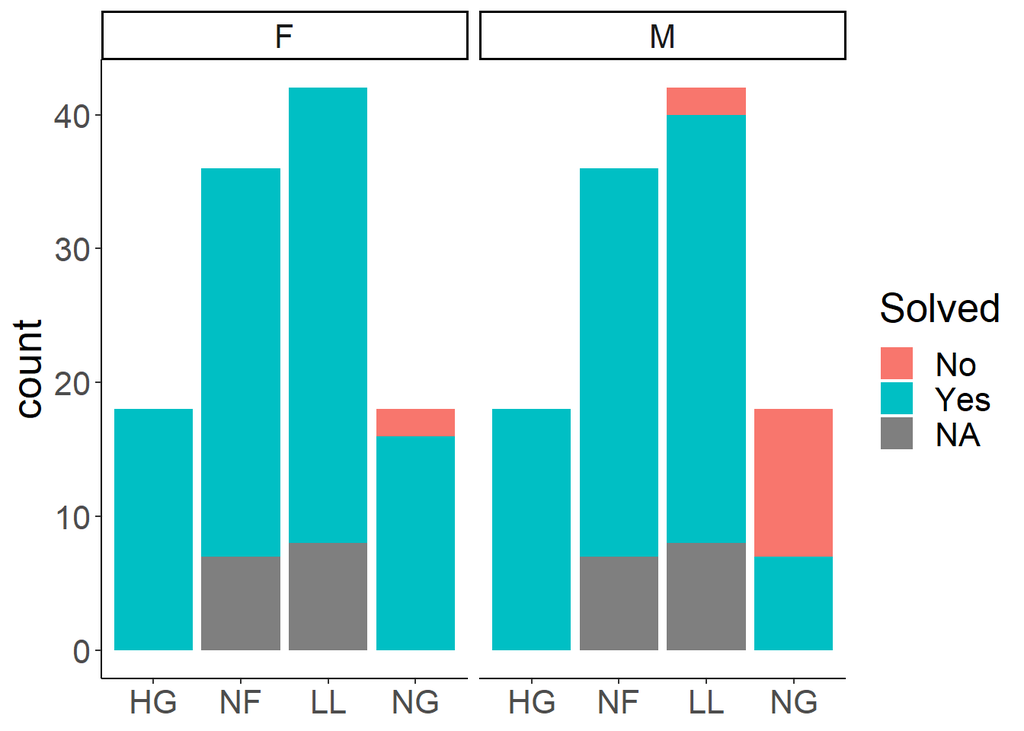

# Problem 10

We want to see if there is any difference in the time it takes the birds to complete the puzzle and how late in the season the trial was run. Try to recreate the following figure (use `theme_classic`, `geom_smooth` with `method="lm"`, set all text to `size=20`, and make the points `size=3`). (Hint: it won’t work–keep reading to figure out why):

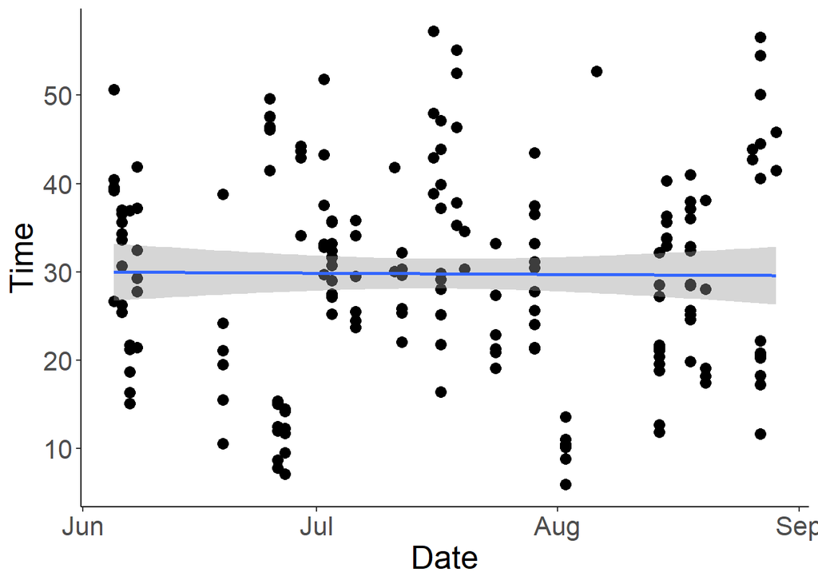

What went wrong? You likely created the following figure. Try and find the problem first, then once you think you’ve got it figured out, hover over the text below to see the answer.

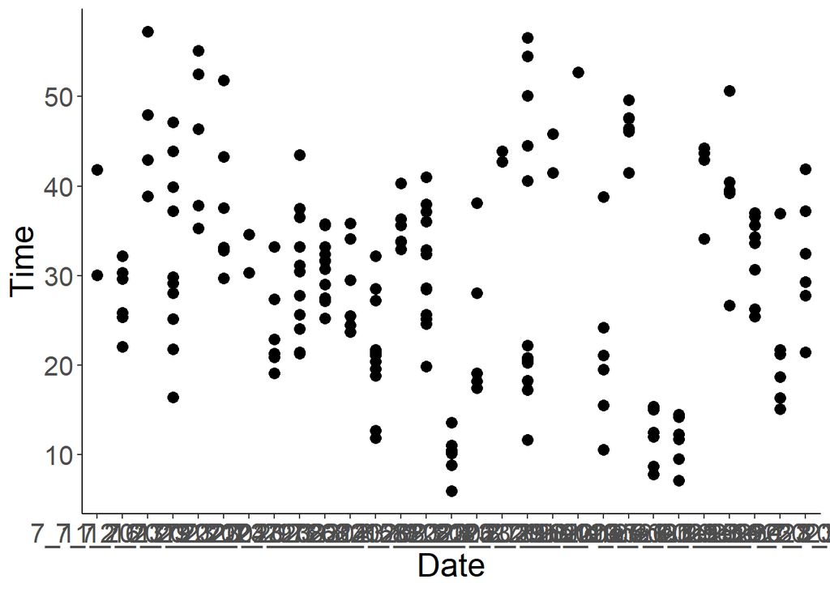

Solution: The `Date` column is currently not a date-object. Even worse–the dates are saved in two different formats!

### Problem 10a.

Wrangle the `Date` column into a date object (hint: it’s easier than it seems using the `lubridate` package, which should have loaded with the `tidyverse` package if it’s up to date). Once you’ve done that, recreate the above figure and interpret it.

Extra Credit: Look to see if there is any difference based on the field site or sex.

```
## # A tibble: 6 × 9
##   Date       Sex   Site  Box   Trial  Time SiteName     ContLevel Solved
##   <date>     <chr> <fct> <chr> <chr> <dbl> <fct>            <dbl> <chr>
## 1 2023-08-14 M     HG    1     0.5    21.1 Horton Grove         4 Yes
## 2 2023-08-14 M     HG    1     1      32.2 Horton Grove         4 Yes
## 3 2023-08-14 M     HG    1     2      20.4 Horton Grove         4 Yes
## 4 2023-08-14 M     HG    1     3      19.6 Horton Grove         4 Yes
## 5 2023-08-14 M     HG    1     4      18.8 Horton Grove         4 Yes
## 6 2023-08-14 M     HG    1     5      11.9 Horton Grove         4 Yes
```

# Problem 11

We want to see if there is any difference in the rates at which the birds learn by `Site` or `Sex`. First, we want to change the `Trials` from `0.5 - 5` to `0 - 5` so that they are spaced evenly. Using `mutate()` and a vectorized `if_else()` statement, change `Trial` == `0.5` to `0`. (Hint: if you are running into an error, check to make sure that the `Trial` column is numeric).

```
## # A tibble: 6 × 9
##   Date       Sex   Site  Box   Trial  Time SiteName     ContLevel Solved
##   <date>     <chr> <fct> <chr> <dbl> <dbl> <fct>            <dbl> <chr>
## 1 2023-08-14 M     HG    1         0  21.1 Horton Grove         4 Yes
## 2 2023-08-14 M     HG    1         1  32.2 Horton Grove         4 Yes
## 3 2023-08-14 M     HG    1         2  20.4 Horton Grove         4 Yes
## 4 2023-08-14 M     HG    1         3  19.6 Horton Grove         4 Yes
## 5 2023-08-14 M     HG    1         4  18.8 Horton Grove         4 Yes
## 6 2023-08-14 M     HG    1         5  11.9 Horton Grove         4 Yes
```

Complete ONE of the following two problems (you don’t have to do both):

### Problem 11a

Create the following figure and interpret it:

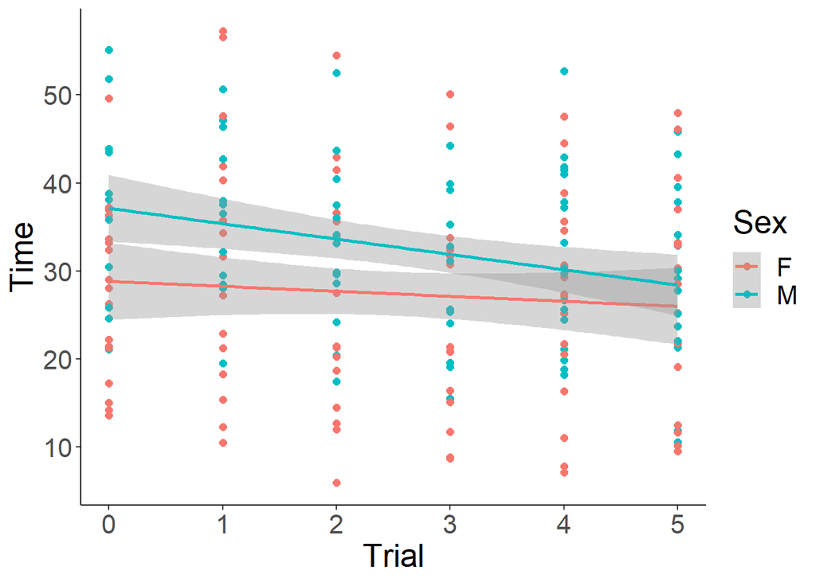

### Problem 11b

Create the following figure and interpret it. I am setting these colors using `scale_color_viridis(discrete=True)` using the `viridis` package. You are welcome to do the same, or pick your own colors.

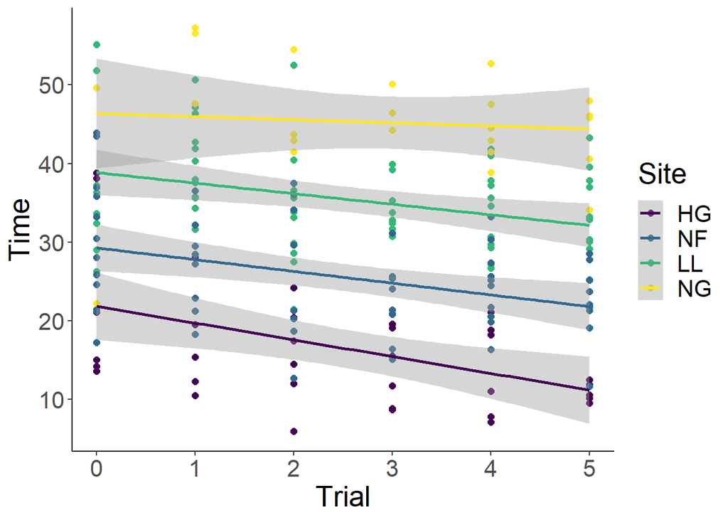

# Problem 12

We have now reached the end of our section on R. Take a moment now to compile any useful resources, functions, instructions for your future self, problems you ran into and solved, etc. into your Learning Notebook (you don’t need to show us anything for this problem).